# Exploratory Data analysis on White Wine Dataset

The project is for looking and finding the deep insights of the white wine dataset which also brings the conclusion to the factors responsible for affecting the qulaity of wine.

The data used is based on the wine quality dataset as avialable on [link](https://raw.githubusercontent.com/Shreyas3108/May28thMLbatcj/master/wineQualityWhites.csv).

The features of the dataset are as follows ,This dataset has 12 variables which contains 8 variables of ingredient, 3 variables of physical properity, 1 variable of subjective 'quantity' rating.

The format includes Univariate, Bivariate, and Multivariate analyses with a final summary and reflection at the end.

```python
from IPython.display import HTML

HTML('''<script>
code_show=true;
function code_toggle() {
 if (code_show){
 $('div.input').hide();
 } else {
 $('div.input').show();
 }
 code_show = !code_show
}
$( document ).ready(code_toggle);
</script>
<form action="javascript:code_toggle()"><input type="submit" value="Click here to toggle on/off the raw code."></form>''')
```

## Data description

The data is in csv format.In computing, a comma-separated values (CSV) file stores tabular data (numbers and text) in plain text. Each line of the file is a data record. Each record consists of one or more fields, separated by commas. All wines are produced in a particular area of Portugal. Data are collected on 12 different properties of the wines one of which is Quality, based on sensory data, and the rest are on chemical properties of the wines including density, acidity, alcohol content etc. All chemical properties of wines are continuous variables. Quality is an ordinal variable with possible ranking from 1 (worst) to 10 (best). Each variety of wine is tasted by three independent tasters and the final rank assigned is the median rank given by the tasters.

## Attribute Information:

Input variables (based on physicochemical tests)

1. Fixed acidity: most acids involved with wine or fixed or nonvolatile (do not evaporate readily) (tartaric acid - g / dm^3^)
2. Volatile acidity: the amount of acetic acid in wine, which at too high of levels can lead to an unpleasant, vinegar taste.
3. Citric acid: found in small quantities, citric acid can add 'freshness' and flavor to wines. (g / dm^3)
4. residual sugar: the amount of sugar remaining after fermentation stops, it's rare to find wines with less than 1 gram/liter and wines with greater than 45 grams/liter are considered sweet.
5. Chlorides: the amount of salt in the wine.
6. free sulfur dioxide: the free form of SO2 exists in equilibrium between molecular SO2 (as a dissolved gas) and bisulfite ion; it prevents microbial growth and the oxidation of wine. (mg / dm^3^)
7. Total sulfur dioxide: amount of free and bound forms of S02; in low concentrations, SO2 is mostly undetectable in wine, but at free SO2 concentrations over 50 ppm, SO2 becomes evident in the nose and taste of wine. (mg / dm^3^)
8. density: the density of water is close to that of water depending on the percent alcohol and sugar content. (g / cm^3^)
9. pH: describes how acidic or basic a wine is on a scale from 0 (very acidic) to 14 (very basic); most wines are between 3-4 on the pH scale.
10. Sulphates: a wine additive which can contribute to sulfur dioxide gas (S02) levels, wich acts as an antimicrobial and antioxidant. (potassium sulphate - g / dm^3^)
11. Alcohol: the percent alcohol content of the wine. (% by volume)
12. Quality: The rating given on the basis of the taste.

```python
import numpy as np
import pandas as pd
import matplotlib.pyplot as plt
%matplotlib inline
import seaborn as sns
```

[figure not shown]

```
    Let us import the dataset and view the first five rows.
```

```python
df=pd.read_csv("https://raw.githubusercontent.com/Shreyas3108/May28thMLbatcj/master/wineQualityWhites.csv")
df.pop('Unnamed: 0')
df.head()
```

|  | fixed.acidity | volatile.acidity | citric.acid | residual.sugar | chlorides | free.sulfur.dioxide | total.sulfur.dioxide | density | pH | sulphates | alcohol | quality |
| --- | --- | --- | --- | --- | --- | --- | --- | --- | --- | --- | --- | --- |
| 0 | 7.0 | 0.27 | 0.36 | 20.7 | 0.045 | 45.0 | 170.0 | 1.0010 | 3.00 | 0.45 | 8.8 | 6 |
| 1 | 6.3 | 0.30 | 0.34 | 1.6 | 0.049 | 14.0 | 132.0 | 0.9940 | 3.30 | 0.49 | 9.5 | 6 |
| 2 | 8.1 | 0.28 | 0.40 | 6.9 | 0.050 | 30.0 | 97.0 | 0.9951 | 3.26 | 0.44 | 10.1 | 6 |
| 3 | 7.2 | 0.23 | 0.32 | 8.5 | 0.058 | 47.0 | 186.0 | 0.9956 | 3.19 | 0.40 | 9.9 | 6 |
| 4 | 7.2 | 0.23 | 0.32 | 8.5 | 0.058 | 47.0 | 186.0 | 0.9956 | 3.19 | 0.40 | 9.9 | 6 |

```python
print('Shape of dataframe:')
df.shape
```

```
Shape of dataframe:
```

```
(4898, 12)
```

```python
print('Size of dataframe:')
df.size
```

```
Size of dataframe:
```

```
58776
```

```python
print('Statistical Description')
df.describe()
```

```
Statistical Description
```

|  | fixed.acidity | volatile.acidity | citric.acid | residual.sugar | chlorides | free.sulfur.dioxide | total.sulfur.dioxide | density | pH | sulphates | alcohol | quality |
| --- | --- | --- | --- | --- | --- | --- | --- | --- | --- | --- | --- | --- |
| count | 4898.000000 | 4898.000000 | 4898.000000 | 4898.000000 | 4898.000000 | 4898.000000 | 4898.000000 | 4898.000000 | 4898.000000 | 4898.000000 | 4898.000000 | 4898.000000 |
| mean | 6.854788 | 0.278241 | 0.334192 | 6.391415 | 0.045772 | 35.308085 | 138.360657 | 0.994027 | 3.188267 | 0.489847 | 10.514267 | 5.877909 |
| std | 0.843868 | 0.100795 | 0.121020 | 5.072058 | 0.021848 | 17.007137 | 42.498065 | 0.002991 | 0.151001 | 0.114126 | 1.230621 | 0.885639 |
| min | 3.800000 | 0.080000 | 0.000000 | 0.600000 | 0.009000 | 2.000000 | 9.000000 | 0.987110 | 2.720000 | 0.220000 | 8.000000 | 3.000000 |
| 25% | 6.300000 | 0.210000 | 0.270000 | 1.700000 | 0.036000 | 23.000000 | 108.000000 | 0.991723 | 3.090000 | 0.410000 | 9.500000 | 5.000000 |
| 50% | 6.800000 | 0.260000 | 0.320000 | 5.200000 | 0.043000 | 34.000000 | 134.000000 | 0.993740 | 3.180000 | 0.470000 | 10.400000 | 6.000000 |
| 75% | 7.300000 | 0.320000 | 0.390000 | 9.900000 | 0.050000 | 46.000000 | 167.000000 | 0.996100 | 3.280000 | 0.550000 | 11.400000 | 6.000000 |
| max | 14.200000 | 1.100000 | 1.660000 | 65.800000 | 0.346000 | 289.000000 | 440.000000 | 1.038980 | 3.820000 | 1.080000 | 14.200000 | 9.000000 |

```python
print('Null Check:')
df.isnull().sum()
```

```
Null Check:
```

```
fixed.acidity           0
volatile.acidity        0
citric.acid             0
residual.sugar          0
chlorides               0
free.sulfur.dioxide     0
total.sulfur.dioxide    0
density                 0
pH                      0
sulphates               0
alcohol                 0
quality                 0
dtype: int64
```

Since we don't have any null values so we don't have to apply any method to handle it.

# Univariate Analysis

Univariate means one variable analysis. The key pointers to the Univaraite analysis are to find out the outliers present in the data. We also tend to find the dsitribution of the data on the dataset which can further help us for the Bivaraite/Multivariate analysis.

## Quality Countplot

Here is the quality countplot. From the plot we can learn:

1. The quality rating 6 is highest in number and rating 5 is second highest in number.
2. We can see only few number of ratings are given as '8' and '9' which are quite low compared to mediocre ratings.It suggests that most of the tasters were not given the best quality of wine for testing.
3. Since most of the ratings are mediocre ,we can say that most wines are of average quality.
4. Even though quality is meant to be a rating from 0 to 10, only 3 through 9 are used.

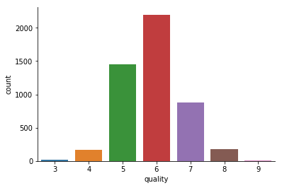

```python
sns.countplot(x='quality',data=df)
sns.despine()
```

## Sulphates Distribution Plot

From the sulphate distribution plot we can see that:

1. The distribution is slighty skewed and have outliers.
2. In most of the bottles the level of sulphates are found between 0.3 to 0.6 gm/dm^3.
3. Few wines have level of sulphates more than .8 gm/dm^3.

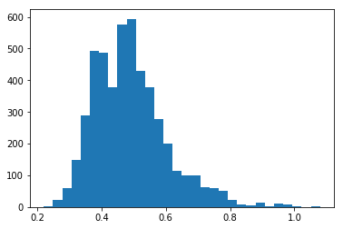

```python
plt.hist(x = 'sulphates' , data = df , bins = 30)
plt.show()
```

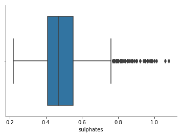

```python
sns.boxplot(x='sulphates',data=df)
sns.despine()
```

## Alcohol Distribution Plot

From the alcohol distribution plot we can see that:

1. We can find that mode of alcohol levels is less than mean as most of the wines are having alcohol level in between 9 to 9.8 whereas mean is 10.51.
2. Alcohol level more than 11.5 are less in number than the mean alcohol level.

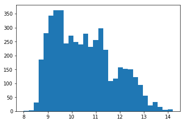

```python
plt.hist(x='alcohol',data=df,bins=30)
plt.show()
```

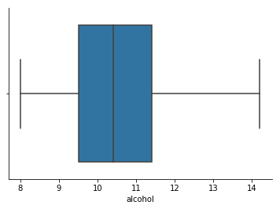

```python
sns.boxplot(df['alcohol'])
sns.despine()
```

## pH Distribution Plot

From the pH distribution plot we can see that:

1. Few wines has pH value more than 3.5 suggesting that there are bottle of wines having pH value more than mean value.
2. Most pH values are between 3.1 to 3.3 suggesting that it is mediocre acidic.

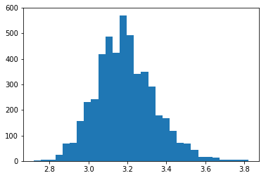

```python
plt.hist(x='pH',data=df,bins=30)
plt.show()
```

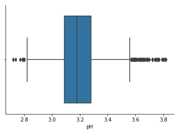

```python
sns.boxplot(df['pH'])
sns.despine()
```

## Density Distribution Plot

From the density distribution plot we can see that:

1. The density of the wines are found mostly between .990 to .998 g/ L.
2. Few wines have density more than 1.01 g/L suggesting us that there are outliers too.

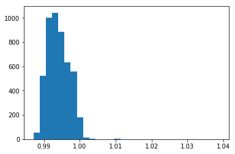

```python
plt.hist(x='density',data=df,bins=30)
plt.show()
```

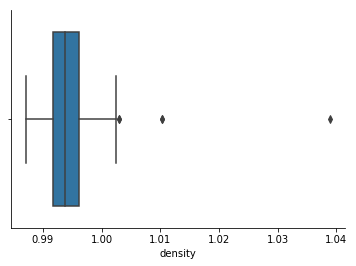

```python
sns.boxplot(df['density'])
sns.despine()
```

## Total Sulphur Dioxide Distribution Plot

From the total sulphur dioxide distribution plot we can see that:

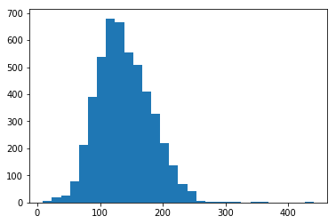

```python
plt.hist(x='total.sulfur.dioxide',data=df,bins=30)
plt.show()
```

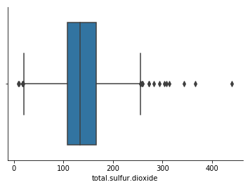

```python
sns.boxplot(x='total.sulfur.dioxide',data=df)
sns.despine()
```

## Free Sulphur Dioxide Distribution Plot

From the free sulphur dioxide distribution plot we can see that:

1. Concentration of free sulphur dioxide is mostly in between 20 to 60 g/dm^3.
2. Some wines have density more than 90 g/dm^3.

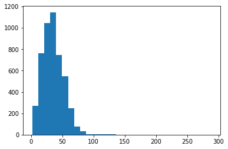

```python
plt.hist(x='free.sulfur.dioxide',data=df,bins=30)
plt.show()
```

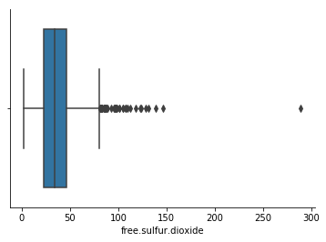

```python
sns.boxplot(x='free.sulfur.dioxide',data=df)
sns.despine()
```

## Chlorides Distribution Plot

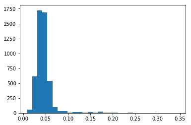

```python
plt.hist(x='chlorides',data=df,bins=30)
plt.show()
```

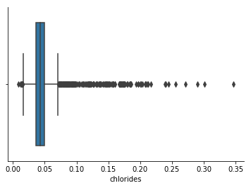

```python
sns.boxplot(x='chlorides',data=df)
sns.despine()
```

## Fixed Acidity Dioxide Distribution Plot

From the fixed acidity acid distribution plot we can see that, most of the wines have fixed acidity between 6 to 8g/dm^3. In order to keep the acid non volatile, level of fixed acidity is kept between 6 to 8 g/dm^3. Here,we have outliers in both the direction too.

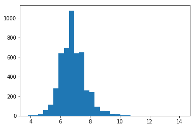

```python
plt.hist(x='fixed.acidity',data=df,bins=30)
plt.show()
```

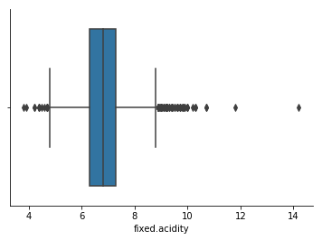

```python
sns.boxplot(x='fixed.acidity',data=df)
sns.despine()
```

## Volatile Acidity Dioxide Distribution Plot

From the volatile acidity acid distribution plot we can see that:

1. Most of the wines have volatile acidty between .15 to .35 g.dm^3 as if more level is maintained then the wine will give unplesant smell.
2. We have few wines having volatile acidity more than .40.

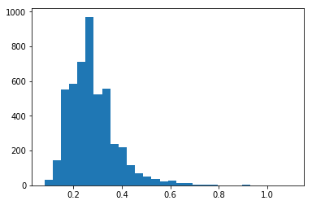

```python
plt.hist(x='volatile.acidity',data=df,bins=30)
plt.show()
```

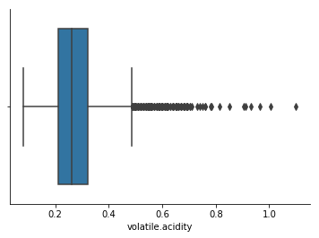

```python
sns.boxplot(x='volatile.acidity',data=df)
sns.despine()
```

## Citric Acid Distribution Plot

From the citric acid distribution plot we can see that:

1. Most of the wines have concentration level of citric acid between .29 to .40
2. Also we have wines having concentration level of citric acid more than .6 .

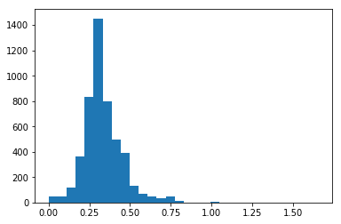

```python
plt.hist(x='citric.acid',data=df,bins=30)
plt.show()
```

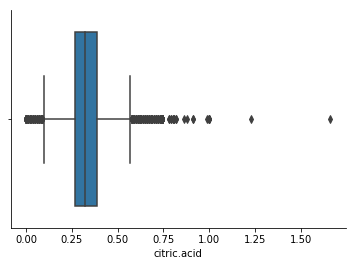

```python
sns.boxplot(x='citric.acid',data=df)
sns.despine()
```

## Residual Sugar Distribution Plot

From the residual sugar distribution plot we can see that:

1. Most of the wines have residual sugar level less than 15 g/L suggesting that the sweetness factor of most of the wines have less than of the most sweetest wine.
2. However,we can see that few wines having residual sugur level more than 25 g/L.

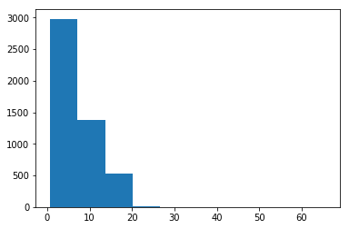

```python
plt.hist(x='residual.sugar',data=df)
plt.show()
```

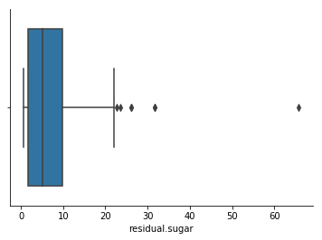

```python
sns.boxplot(x='residual.sugar',data=df)
sns.despine()
```

# Bivariate Analysis

Two variable analysis. We want to find out the relationship between two points. Explore the data.

```python
df.corr()
```

|  | fixed.acidity | volatile.acidity | citric.acid | residual.sugar | chlorides | free.sulfur.dioxide | total.sulfur.dioxide | density | pH | sulphates | alcohol | quality |
| --- | --- | --- | --- | --- | --- | --- | --- | --- | --- | --- | --- | --- |
| fixed.acidity | 1.000000 | -0.022697 | 0.289181 | 0.089021 | 0.023086 | -0.049396 | 0.091070 | 0.265331 | -0.425858 | -0.017143 | -0.120881 | -0.113663 |
| volatile.acidity | -0.022697 | 1.000000 | -0.149472 | 0.064286 | 0.070512 | -0.097012 | 0.089261 | 0.027114 | -0.031915 | -0.035728 | 0.067718 | -0.194723 |
| citric.acid | 0.289181 | -0.149472 | 1.000000 | 0.094212 | 0.114364 | 0.094077 | 0.121131 | 0.149503 | -0.163748 | 0.062331 | -0.075729 | -0.009209 |
| residual.sugar | 0.089021 | 0.064286 | 0.094212 | 1.000000 | 0.088685 | 0.299098 | 0.401439 | 0.838966 | -0.194133 | -0.026664 | -0.450631 | -0.097577 |
| chlorides | 0.023086 | 0.070512 | 0.114364 | 0.088685 | 1.000000 | 0.101392 | 0.198910 | 0.257211 | -0.090439 | 0.016763 | -0.360189 | -0.209934 |
| free.sulfur.dioxide | -0.049396 | -0.097012 | 0.094077 | 0.299098 | 0.101392 | 1.000000 | 0.615501 | 0.294210 | -0.000618 | 0.059217 | -0.250104 | 0.008158 |
| total.sulfur.dioxide | 0.091070 | 0.089261 | 0.121131 | 0.401439 | 0.198910 | 0.615501 | 1.000000 | 0.529881 | 0.002321 | 0.134562 | -0.448892 | -0.174737 |
| density | 0.265331 | 0.027114 | 0.149503 | 0.838966 | 0.257211 | 0.294210 | 0.529881 | 1.000000 | -0.093591 | 0.074493 | -0.780138 | -0.307123 |
| pH | -0.425858 | -0.031915 | -0.163748 | -0.194133 | -0.090439 | -0.000618 | 0.002321 | -0.093591 | 1.000000 | 0.155951 | 0.121432 | 0.099427 |
| sulphates | -0.017143 | -0.035728 | 0.062331 | -0.026664 | 0.016763 | 0.059217 | 0.134562 | 0.074493 | 0.155951 | 1.000000 | -0.017433 | 0.053678 |
| alcohol | -0.120881 | 0.067718 | -0.075729 | -0.450631 | -0.360189 | -0.250104 | -0.448892 | -0.780138 | 0.121432 | -0.017433 | 1.000000 | 0.435575 |
| quality | -0.113663 | -0.194723 | -0.009209 | -0.097577 | -0.209934 | 0.008158 | -0.174737 | -0.307123 | 0.099427 | 0.053678 | 0.435575 | 1.000000 |

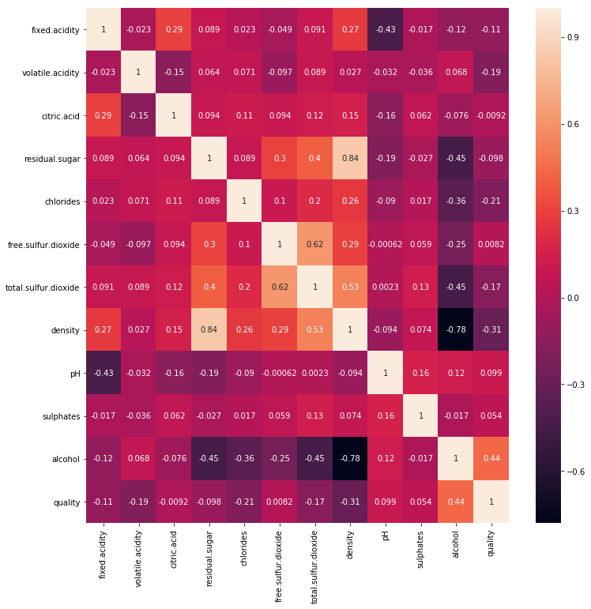

```python
plt.figure(figsize=(12,12))
sns.heatmap(df.corr(),annot=True)
plt.show()
```

### Density Vs Residual Sugar

From the plot we learn that:

1. Density and Residual Sugar are having correlation coefficient of 0.84.
2. We can see the trend that increasing the level of residual sugar increases the density of the wine.Wines with less residual sugar are having less density.
3. We can find the density of wine more than 1.03 g/L for residual sugar level 60+ g/dm^3.

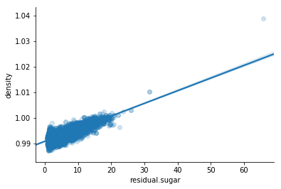

```python
sns.regplot(x='residual.sugar', y='density',data=df,scatter_kws={'alpha':0.2})
sns.despine()
```

### Alcohol Vs Residual Sugar

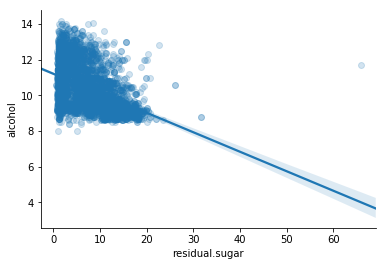

```python
sns.regplot(x='residual.sugar', y='alcohol',data=df,scatter_kws={'alpha':0.2})
sns.despine()
```

### Alcohol Vs Density

From the plot we learn that:

1. Density and alcohol are having correlation coefficient of -0.78.
2. We can see the trend that increasing the level of alcohol decreases the density of the wine.
3. Wines with level of alcohol more than 12 g/dm^3 have density less than 1.00 g/L.
4. However,very few wines haing alcohol level more between 11 to 12 g/dm^3 has desnity more than 1.03 g/L.

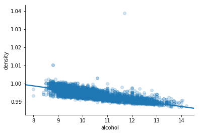

```python
sns.regplot(x='alcohol', y='density',data=df,scatter_kws={'alpha':0.2})
sns.despine()
```

### pH Vs Fixed Acidity

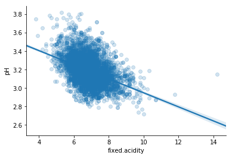

```python
sns.regplot(x='fixed.acidity', y='pH',data=df,scatter_kws={'alpha':0.2})
sns.despine()
```

### Total Sulphur Dioxide Vs Desnity

From the plot we learn that:

1. Total sulphur dioxide and density are having correlation coefficient of 0.53.
2. We can see the trend that increasing the level of total sulphur dioxide increases the density of the wine.
3. Wines having the concentration level of total sulphur dioxide in between 100 to 200 g/dm^3 have density between .985 to .998 gm/L.
4. However ,few wines with the concentration level of total sulphur dioxide more than 200g/dm^3 has desnity less than 0.99 g/L.

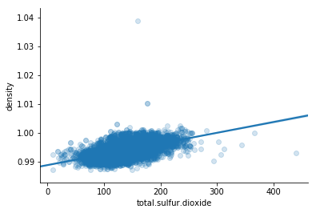

```python
sns.regplot(x='total.sulfur.dioxide', y='density',data=df,scatter_kws={'alpha':0.2})
sns.despine()
```

### Quality Vs Alcohol

From quality Vs alcohol plot we have:

1. Alcohol and Quality are having correlation coefficient of 0.44.
2. Better Quality wines have more Alcohol concentration.
3. We can see that Average Quality wines ( 5 and 6 ) have most of their alcohol concentration in the range 8.5 to 10 for quality rating 5 and 8.5-12.5 for Quality rating 6
4. Quality rating 7 can be seen having more number of wines with Alcohol concentration 10+.
5. Quality rating 8 can be seen having more number of wines with Alcohol concentration 11+.
6. However we can also notice for few wines of quality rating more 8 are having alcohol level less than 9.

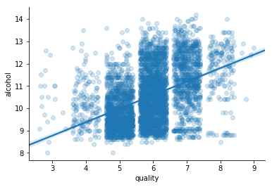

```python
sns.regplot(x = 'quality',y = 'alcohol',data = df , x_jitter=0.4, scatter_kws={'alpha':0.2})
sns.despine()
```

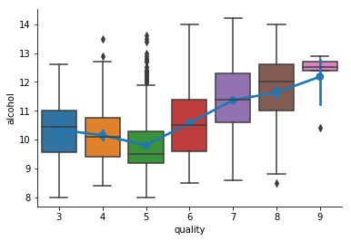

```python
sns.boxplot(x = 'quality', y= 'alcohol',data = df)
sns.pointplot(x='quality',y='alcohol',data = df)
sns.despine()
```

### Total Sulphur Dioxide Vs Residual Sugar

From the plot we learn that:

1. Total sulphur dioxide and residual sugar are having correlation coefficient of 0.4.
2. We can see the trend that increasing the level of total sulphur dioxide ,we must increase the concentration of residual sugar too.
3. Wines having the concentration level of total sulphur dioxide in between 100 to 200 g/dm^3 have concentration of resdual sugar between 0 to 15 gm/L.
4. However, few wines with the increase in concentration level of sulphur dixode the concentration of resdual sugar remains near 0 only, eg.wines with the increase in concentration level of sulphur dixode more than 250 have mostly concentration of resdual sugar near 0.

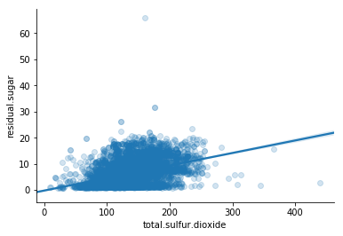

```python
sns.regplot(x='total.sulfur.dioxide', y='residual.sugar',data=df,scatter_kws={'alpha':0.2})
sns.despine()
```

## Mulivariate Analysis

Multivariate analysis means analysis of more than two variables.

### Alcohol vs Density in terms of Quality plot.

#### Inferences from the Alcohol vs Density in terms of Quality plot.

From the below Facet plots , we can establish that due to Alcohol's relation with Quality. Higher quality of wine contains higher Alcohol concentration levels. However we didn't notice any big difference in terms of density.

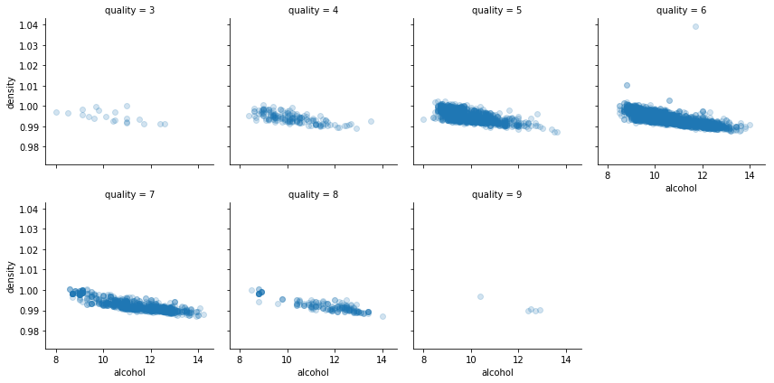

```python
grid = sns.FacetGrid(df, col='quality',col_wrap = 4)
grid.map(plt.scatter,'alcohol','density',alpha = 0.2)
```

### Alcohol vs Residual Sugar in terms of Quality plot.

#### Inferences from the below Alcohol vs Residual Sugar in terms of Quality plot.

As mentioned earlier higher quality wines have higher alcohol level.However for all the quality of wines the residual sugar level is less than 20 only.But very few medicore ratings has residual sugar level more than 20.We can see that for almost all quality ratings of wines(4-9) on increasing the alcohol level, the level of residual sugar level decreases.While wines with quality rated 3 has first incresing and then decreasing level of residual sugar on increasing the alcohol level. we can say ,the residual level doesn't really effects the quality of the wine.

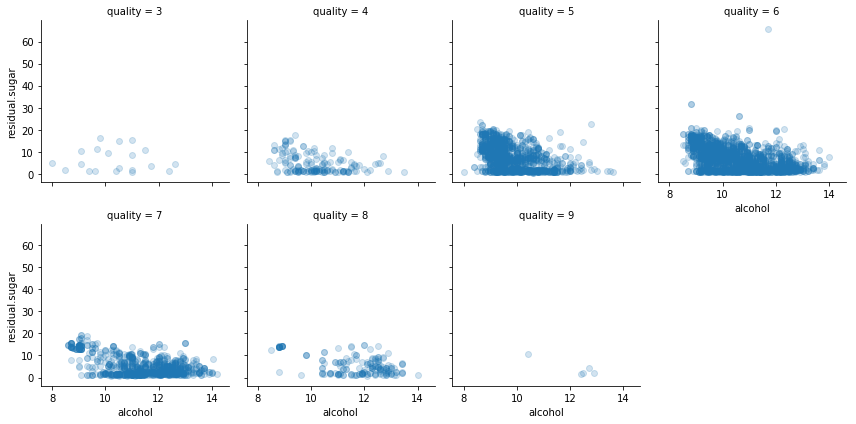

```python
grid = sns.FacetGrid(df, col='quality',col_wrap = 4)
grid.map(plt.scatter,'alcohol','residual.sugar',alpha = 0.2)
sns.despine()
```

### Alcohol vs Total Sulphur Dioxode in terms of Quality plot.

#### Inferencces:

We can see that on increasing alcohol level for mediocre(5,6,and 7) quality of wine decreases slightly in the total sulphur dioxode level.However we can't see any significant difference for quality ratings 8 and 9 as the level of total sulphur dioxide level remains almost same.

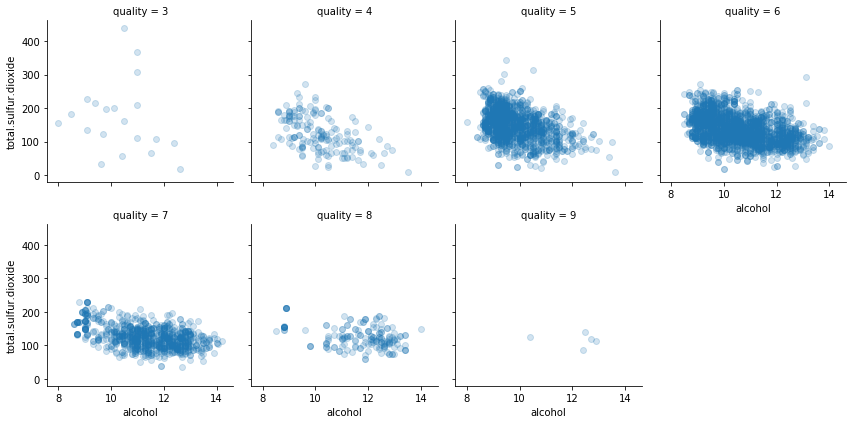

```python
grid = sns.FacetGrid(df, col='quality',col_wrap = 4)
grid.map(plt.scatter,'alcohol','total.sulfur.dioxide',alpha = 0.2)
sns.despine()
```

## Final Plot Section

### Quality Vs Alcohol

#### Infereces :

We can say that the amount of alcohol is decides the quality of the wines. To have the a average quality of wines the avergae alcohol level in the wines must be around 10.29 by volume.To have a good quality of wines one must keep the alcohol level more than 12 by volume .

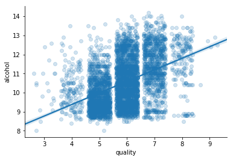

```python
sns.regplot(x = 'quality',y = 'alcohol',data = df , x_jitter=0.4, scatter_kws={'alpha':0.2})
sns.despine()
```

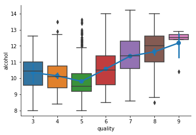

```python
sns.boxplot(x = 'quality', y= 'alcohol',data = df)
sns.pointplot(x='quality',y='alcohol',data = df)
sns.despine()
```

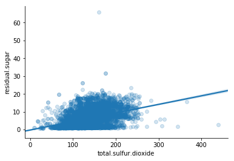

```python
sns.regplot(x='total.sulfur.dioxide', y='residual.sugar',data=df,scatter_kws={'alpha':0.2})
sns.despine()
```

### Density Vs Residual Sugar

#### Infereces :

Density and Residual Sugar are having correlation coefficient of 0.84.We can see that residual Sugar highly effects the density of the wine.On increasing the level of residual sugar increases the density of the wine.Wines with less residual sugar are having less density.

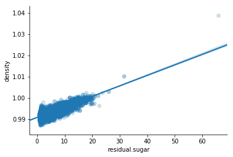

```python
sns.regplot(x='residual.sugar', y='density',data=df,scatter_kws={'alpha':0.2})
sns.despine()
```

# Conclusion

The quality of wines is heavily affected by the alcohol level in the wine.People found wines with more alcohol level better than of less alcohol level.Besides alcohol level there are other factors like fixed and volatile acidity level,residual sugar level,density affecting the quality of wine but are insignificant in compare to alcohol level.

The pH level of wines depends on the fixed acidity as fixed acids(tartaric acid) are the non volatile acids present in the wine.

The density of the wine depends on alcohol level ,residual sugar and total sulphur dioxide level in the wine.On increasing the level of residual sugar or total sulphur dioxide level ,we will get the wine of higher density . While on increasing the alcohol level ,density of wine will get reduced.